# Intro to Geospatial Machine Learning

Public Policy Analytics: Code and Context for Data Science in Government

Ken Steif, PhD

Last Updated 2023-04-08

This week begins our foray into geospatial machine learning. We will read and walk through exercises from Ken Steif’s book outlined in the syllabus. The remaining graded Lab Exercises will be largely drawn from the assignments presented in the Steif text. The assigned readings for this week are available here and may be useful as you make your way through this activity:

- Starmer (2018) [Decision and Classification Trees, Clearly Explained!!!](https://www.youtube.com/watch?v=_L39rN6gz7Y&t=0s)
- Starmer (2018) [Regression Trees, Clearly Explained!!!](https://www.youtube.com/watch?v=g9c66TUylZ4)
- Steif (2021) [Intro to geospatial machine learning, Part 1](https://urbanspatial.github.io/PublicPolicyAnalytics/intro-to-geospatial-machine-learning-part-1.html)
- Steif (2021) [Intro to geospatial machine learning, Part 2](https://urbanspatial.github.io/PublicPolicyAnalytics/intro-to-geospatial-machine-learning-part-2.html)

The first portion of the Steif chapter introduces the machine learning workflow and defines some important terms (e.g., feature engineering, training set, accuracy, etc.). We will skip down to section 3.2 where the data analysis begins in earnest.

# 3.2 Data wrangling - Home price & crime data

After loading the necessary R packages, we specify a list of colors that will be used to generate graphics and execute the **functions.R** script, which loads several custom functions from the text into memory for us. The companion data have been placed in the **data** folder.

As you read, the general aim is to use observed home price data from Boston to train, apply, and evaluate a predictive model of home prices> We pull down the neighborhood boundaries layer from the Boston open data portal, then apply a map projection to convert the data to a projected coordinate system. We also read in tabular data on home sales (i.e., transaction data) and convert it to a points *sf* object.

```r
nhoods <-
  st_read("http://bostonopendata-boston.opendata.arcgis.com/datasets/3525b0ee6e6b427f9aab5d0a1d0a1a28_0.geojson") %>%
  st_transform('ESRI:102286')
boston <- read_csv("./data/bostonHousePriceData_clean.csv", locale = locale(encoding = "latin1"))
boston.sf <-
  boston %>%
  st_as_sf(coords = c("Longitude", "Latitude"), crs = 4326, agr = "constant") %>%
  st_transform('ESRI:102286')
```

The chunk below maps the price per square foot attribute of homes that were sold using a quintiles (i.e., five bins) scheme.

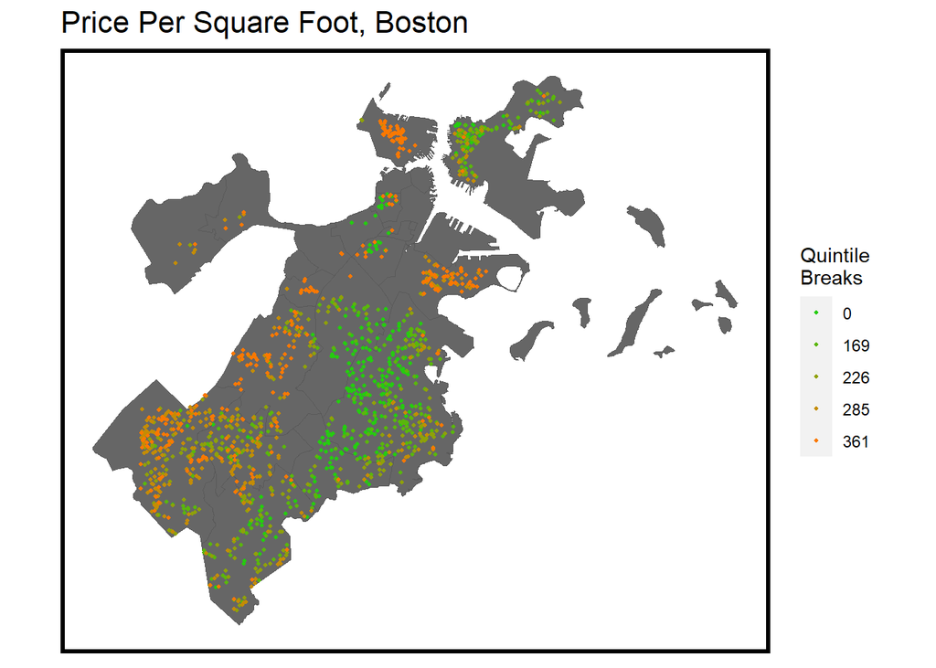

```r
ggplot() +
  geom_sf(data = nhoods, fill = "grey40") +
  geom_sf(data = boston.sf, aes(colour = q5(PricePerSq)),
          show.legend = "point", size = .75) +
  scale_colour_manual(values = palette5,
                   labels=qBr(boston,"PricePerSq"),
                   name="Quintile\nBreaks") +
  labs(title="Price Per Square Foot, Boston") +
  mapTheme()
```

The text asks us to consider these questions after generating the map from the above code chunk:

- What do you notice about the spatial process of home prices? Are they randomly distributed throughout the city or do they seem clustered?
- Why do you think prices are spatially distributed the way they are?

The next step is to bring in crime data as a means of expanding the kinds of characteristics that we can loop into the model **beyond the structural characteristics** of the home. Actual and perceived crime rates can influence property values, and the chunk below gives a sense of what the most commonly reported offenses were at the time.

```r
bostonCrimes <- read_csv("./data/bostonCrimes.csv", locale = locale(encoding = "latin1"))
length(unique(bostonCrimes$OFFENSE_CODE_GROUP))
```

```
## [1] 64
```

```r
group_by(bostonCrimes, OFFENSE_CODE_GROUP) %>%
  summarize(count = n()) %>%
  arrange(-count) %>% top_n(5)
```

| OFFENSE_CODE_GROUP | count |
| --- | --- |
| Motor Vehicle Accident Response | 23717 |
| Larceny | 16869 |
| Drug Violation | 15815 |
| Other | 12797 |
| Medical Assistance | 12626 |

The code below restricts the data to only reports of **Aggravated Assault** then uses *ggplot2::stat_density_2d* to derive a kernel density estimate (expected number of aggravated assaults per unit area) from the point locations themselves. Take a moment to inspect arguments that you do not recognize (e.g., the attribute-geometry-relationship argument in `st_as_sf`). Also, the dot-dot syntax **..level..** indicates a computed variable called **level** that is being created when the code runs.

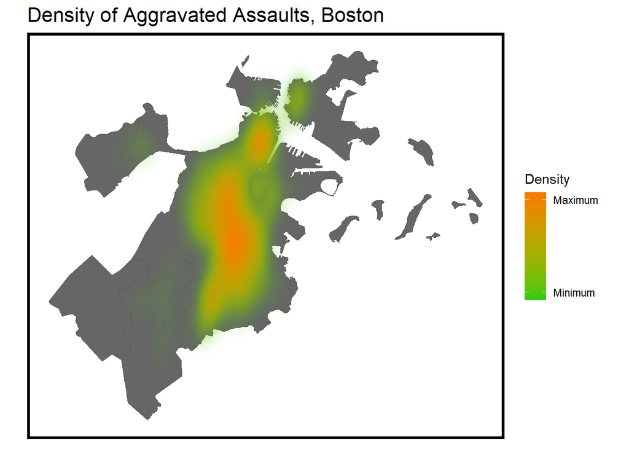

```r
bostonCrimes.sf <-
  bostonCrimes %>%
    filter(OFFENSE_CODE_GROUP == "Aggravated Assault",
           Lat > -1) %>%
    dplyr::select(Lat, Long) %>%
    na.omit() %>%
    st_as_sf(coords = c("Long", "Lat"), crs = 4326, agr = "constant") %>%
    st_transform('ESRI:102286') %>%
    distinct()

ggplot() + geom_sf(data = nhoods, fill = "grey40") +
  stat_density2d(data = data.frame(st_coordinates(bostonCrimes.sf)),
                 aes(X, Y, fill = ..level.., alpha = ..level..),
                 linewidth = 0.01, bins = 40, geom = 'polygon') +
  scale_fill_gradient(low = "#25CB10", high = "#FA7800",
                      breaks=c(0.000000003,0.00000003),
                      labels=c("Minimum","Maximum"), name = "Density") +
  scale_alpha(range = c(0.00, 0.35), guide = "none") +
  labs(title = "Density of Aggravated Assaults, Boston") +
  mapTheme()
```

## 3.2.1 Feature Engineering - Measuring exposure to crime

The code chunk below calculates the number of reported aggravated assault incidents within 1/8 of a mile or 660 feet. However, the coordinate system used here appears to be meters, which would make the buffer roughly 0.41 miles rather than 0.125 miles. Let’s just roll with it as written.

```r
boston.sf$crimes.Buffer =
    st_buffer(boston.sf, 660) %>%
    aggregate(mutate(bostonCrimes.sf, counter = 1), ., sum) %>%
    pull(counter)
```

```r
st_c <- st_coordinates

boston.sf <-
  boston.sf %>%
    mutate(
      crime_nn1 = nn_function(st_c(boston.sf), st_c(bostonCrimes.sf), 1),
      crime_nn2 = nn_function(st_c(boston.sf), st_c(bostonCrimes.sf), 2),
      crime_nn3 = nn_function(st_c(boston.sf), st_c(bostonCrimes.sf), 3),
      crime_nn4 = nn_function(st_c(boston.sf), st_c(bostonCrimes.sf), 4),
      crime_nn5 = nn_function(st_c(boston.sf), st_c(bostonCrimes.sf), 5))
```

## 3.2.2 Exploratory analysis: Correlation

This portion of the workflow is what might be termed **feature engineering** in data science speak or what we learned a few weeks ago as exploratory data analysis. Pearson correlations can be calculated between pairs of continuous variables, with a higher correlation coefficient suggesting that two variables are closely related. In general, we want to avoid duplication among the **features** included in a predictive model (i.e., collinearity).

- Do you think these **features** are a reasonable place to begin building a predictive model? Which one seems to have the strongest relationship with sales price?
- What other factors would you expect to be most important for predicting home prices?

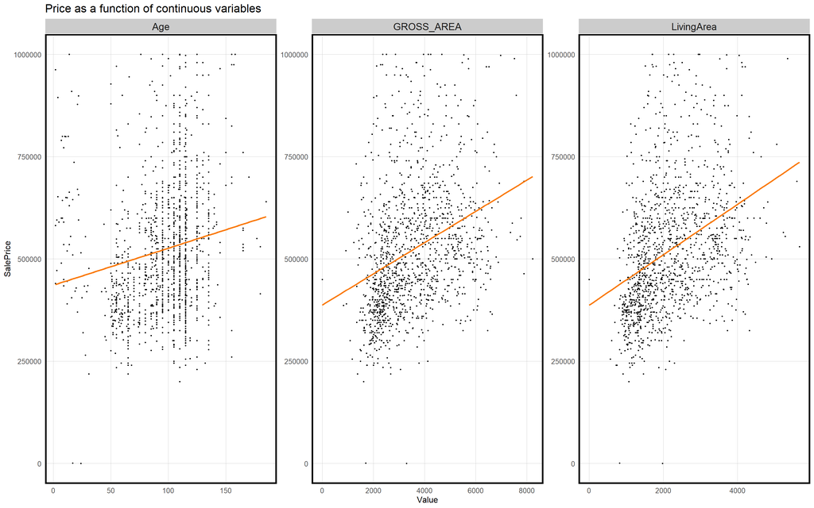

```r
st_drop_geometry(boston.sf) %>%
  mutate(Age = 2015 - YR_BUILT) %>%
  dplyr::select(SalePrice, LivingArea, Age, GROSS_AREA) %>%
  filter(SalePrice <= 1000000, Age < 500) %>%
  gather(Variable, Value, -SalePrice) %>%
   ggplot(aes(Value, SalePrice)) +
     geom_point(size = .5) + geom_smooth(method = "lm", se=F, colour = "#FA7800") +
     facet_wrap(~Variable, ncol = 3, scales = "free") +
     labs(title = "Price as a function of continuous variables") +
     plotTheme()
```

Scatterplots and Pearson correlations ar not appropriate for categorical variables. Instead, the code chunk below uses our old friend the barchart to visualize these relationships 😉 Note the use of the `stat = "summary"` argument (see the [documentation here](https://ggplot2.tidyverse.org/reference/stat_summary.html)).

```
## No summary function supplied, defaulting to `mean_se()`
## No summary function supplied, defaulting to `mean_se()`
## No summary function supplied, defaulting to `mean_se()`
```

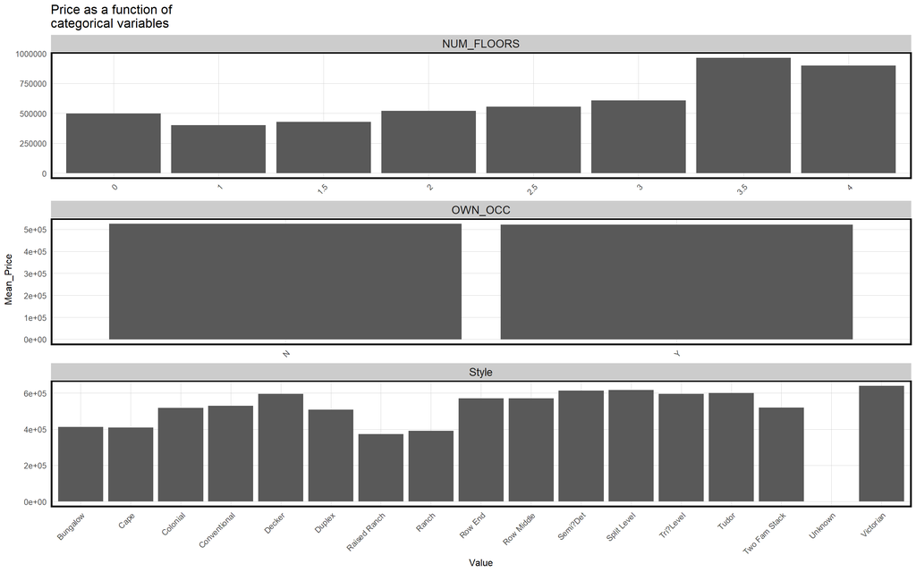

```r
boston %>%
  dplyr::select(SalePrice, Style, OWN_OCC, NUM_FLOORS) %>%
  mutate(NUM_FLOORS = as.factor(NUM_FLOORS)) %>%
  filter(SalePrice <= 1000000) %>%
  gather(Variable, Value, -SalePrice) %>%
   ggplot(aes(Value, SalePrice)) +
     geom_bar(position = "dodge", stat = "summary", fun.y = "mean") +
     facet_wrap(~Variable, ncol = 1, scales = "free") +
     labs(title = "Price as a function of\ncategorical variables", y = "Mean_Price") +
     plotTheme() + theme(axis.text.x = element_text(angle = 45, hjust = 1))
```

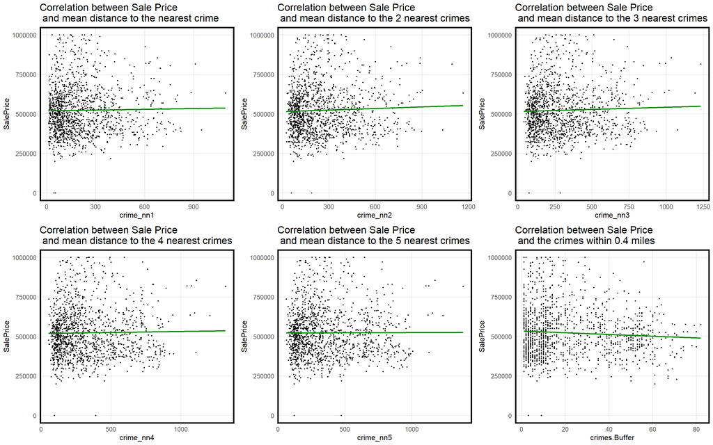

```r
options(scipen = 999)

plot.1 <- boston.sf %>%
   filter(SalePrice <= 1000000) %>%
  ggplot(mapping = aes(x = crime_nn1, y = SalePrice)) +
     geom_point(size = .5) + geom_smooth(method = "lm", se=F, colour = "green4") +
     labs(title = "Correlation between Sale Price \n and mean distance to the nearest crime") +
     plotTheme()

plot.2 <-  boston.sf %>%
   filter(SalePrice <= 1000000) %>%
  ggplot(mapping = aes(x = crime_nn2, y = SalePrice)) +
     geom_point(size = .5) + geom_smooth(method = "lm", se=F, colour = "green4") +
     labs(title = "Correlation between Sale Price \n and mean distance to the 2 nearest crimes") +
     plotTheme()

plot.3 <-  boston.sf %>%
   filter(SalePrice <= 1000000) %>%
  ggplot(mapping = aes(x = crime_nn3, y = SalePrice)) +
     geom_point(size = .5) + geom_smooth(method = "lm", se=F, colour = "green4") +
     labs(title = "Correlation between Sale Price \n and mean distance to the 3 nearest crimes") +
     plotTheme()

plot.4 <-  boston.sf %>%
   filter(SalePrice <= 1000000) %>%
  ggplot(mapping = aes(x = crime_nn4, y = SalePrice)) +
     geom_point(size = .5) + geom_smooth(method = "lm", se=F, colour = "green4") +
     labs(title = "Correlation between Sale Price \n and mean distance to the 4 nearest crimes") +
     plotTheme()

plot.5 <-  boston.sf %>%
   filter(SalePrice <= 1000000) %>%
  ggplot(mapping = aes(x = crime_nn5, y = SalePrice)) +
     geom_point(size = .5) + geom_smooth(method = "lm", se=F, colour = "green4") +
     labs(title = "Correlation between Sale Price \n and mean distance to the 5 nearest crimes") +
     plotTheme()

plot.6 <-  boston.sf %>%
   filter(SalePrice <= 1000000) %>%
  ggplot(mapping = aes(x = crimes.Buffer, y = SalePrice)) +
     geom_point(size = .5) + geom_smooth(method = "lm", se=F, colour = "green4") +
     labs(title = "Correlation between Sale Price \n and the crimes within 0.4 miles") +
     plotTheme()

library(ggpubr)

ggarrange(plot.1, plot.2, plot.3, plot.4, plot.5, plot.6)
```

We have already seen how a correlation matrix represented graphically can be a useful thing. The code chunk below accomplishes this with the present data.

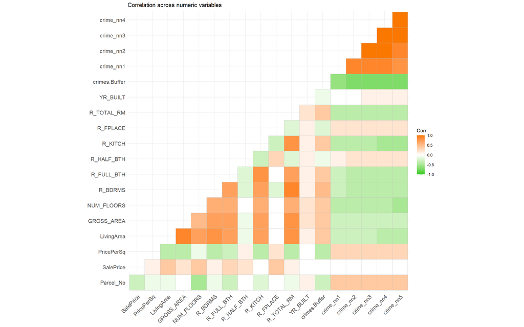

```r
numericVars <-
  select_if(st_drop_geometry(boston.sf), is.numeric) %>% na.omit()

ggcorrplot(
  round(cor(numericVars), 1),
  p.mat = cor_pmat(numericVars),
  colors = c("#25CB10", "white", "#FA7800"),
  type="lower",
  insig = "blank") +
    labs(title = "Correlation across numeric variables")
```

```r
cor.test(boston$LivingArea, boston$SalePrice, method = "pearson")
```

```
##
##  Pearson's product-moment correlation
##
## data:  boston$LivingArea and boston$SalePrice
## t = 14.969, df = 1483, p-value < 0.00000000000000022
## alternative hypothesis: true correlation is not equal to 0
## 95 percent confidence interval:
##  0.3172821 0.4056948
## sample estimates:
##       cor
## 0.3623031
```

# 3.3 Introduction to Regression Trees

This portion of the practice exercise diverges from the Steif text and rather than fitting a linear regressions model, it demonstrates how [decision trees](https://towardsdatascience.com/decision-trees-in-machine-learning-641b9c4e8052) can be used to better understand patterns in a dataset, as well as how these tools can be used for prediction purposes in the R environment.

## 3.3.1 Our regression tree model

```r
# Get neighborhood polygons from the open data portal in GeoJSON format,
# then apply a map projection...
nhoods <-
  st_read("http://bostonopendata-boston.opendata.arcgis.com/datasets/3525b0ee6e6b427f9aab5d0a1d0a1a28_0.geojson") %>%
  st_transform('ESRI:102286')
# Read in the homes data in tabular format with the encoding argument for
# folks using MacOS...
boston <- read_csv("./data/bostonHousePriceData_clean.csv", locale = locale(encoding = "latin1"))


# Convert the homes data to a point sf object with actual geometry...
boston.sf <-
  boston %>%
  st_as_sf(coords = c("Longitude", "Latitude"), crs = 4326, agr = "constant") %>%
  st_transform('ESRI:102286')


# Collapse the many categories on the number of floors attribute,so there is a more manageable number of categories...
boston.sf <-
  boston.sf %>%
  mutate(NUM_FLOORS.cat = case_when(
                  NUM_FLOORS >= 0 & NUM_FLOORS < 3  ~ "Up to 2 Floors",
                  NUM_FLOORS >= 3 & NUM_FLOORS < 4  ~ "3 Floors",
                  NUM_FLOORS > 4                    ~ "4+ Floors"))


# Read in the tabular reported crimes information...
bostonCrimes <- read_csv("./data/bostonCrimes.csv", locale = locale(encoding = "latin1"))


# Extract only reports of aggravated assault and get rid of observations
# with missing values, then generate a point sf object...
bostonCrimes.sf <-
  bostonCrimes %>%
    filter(OFFENSE_CODE_GROUP == "Aggravated Assault",
           Lat > -1) %>%
    dplyr::select(Lat, Long) %>%
    na.omit() %>%
    st_as_sf(coords = c("Long", "Lat"), crs = 4326, agr = "constant") %>%
    st_transform('ESRI:102286') %>%
    distinct()


# This is not how I would have written it, but create a new attribute called
# crimes.Buffer with the number of reported aggravated assaults within the
# specified distance...
boston.sf$crimes.Buffer <- st_buffer(boston.sf, 660) %>%
    aggregate(mutate(bostonCrimes.sf, counter = 1), ., sum) %>%
    pull(counter)
```

The code chunk below partitions (divides) the dataset into two pieces—a [training dataset](https://en.wikipedia.org/wiki/Training,_validation,_and_test_data_sets#Training_data_set) with approximately 60 percent of the observations and a [test dataset](https://en.wikipedia.org/wiki/Training,_validation,_and_test_data_sets#Test_data_set) with the remaining approximately 40 percent of the observations. It also stratifies on neighborhood name, number of floors, structure style, and air conditioning.

```r
# This allows us to reproduce the results in the future...
set.seed(223)

#################################################################################
# This function is part of the caret package and the y argument outlines
# how to stratify the data. From the documentation "the sample is split
# into groups sections based on percentiles and sampling is done within
# these subgroups" and the paste function simply concatenates several features.
#
# This allows us to stratify on multiple features rather than just the outcome
# we are trying to predict (i.e., the training and test sets are more comparable)
#################################################################################
inTrain <- createDataPartition(
              y = paste(boston.sf$Name, boston.sf$NUM_FLOORS.cat,
                        boston.sf$Style, boston.sf$R_AC),
              p = .60, list = FALSE)
boston.training <- boston.sf[inTrain, ]
boston.test <- boston.sf[-inTrain, ]

boston.training %>%
  st_drop_geometry() %>%
  rstatix::get_summary_stats()
```

| variable | n | min | max | median | q1 | q3 | iqr | mad | mean | sd | se | ci |
| --- | --- | --- | --- | --- | --- | --- | --- | --- | --- | --- | --- | --- |
| Parcel_No | 915 | 100032000 | 2102853000.00 | 1604959000.00 | 802845000.00 | 1902423500.0 | 1099578500.00 | 588741942.600 | 1366139174.017 | 668973415.728 | 22115578.935 | 43403213.608 |
| SalePrice | 915 | 0 | 11600000.00 | 515000.00 | 420000.00 | 662350.0 | 242350.00 | 169016.400 | 670551.225 | 681024.397 | 22513.972 | 44185.085 |
| PricePerSq | 915 | 0 | 887.17 | 259.49 | 186.45 | 348.7 | 162.25 | 117.733 | 277.393 | 132.164 | 4.369 | 8.575 |
| LivingArea | 915 | 0 | 9908.00 | 2064.00 | 1458.00 | 2913.0 | 1455.00 | 1025.959 | 2258.343 | 1042.196 | 34.454 | 67.618 |
| GROSS_AREA | 915 | 0 | 11919.00 | 3281.00 | 2446.00 | 4501.0 | 2055.00 | 1404.022 | 3586.763 | 1493.238 | 49.365 | 96.882 |
| NUM_FLOORS | 915 | 0 | 5.00 | 2.00 | 2.00 | 3.0 | 1.00 | 0.741 | 2.156 | 0.688 | 0.023 | 0.045 |
| R_BDRMS | 915 | 0 | 14.00 | 4.00 | 3.00 | 6.0 | 3.00 | 1.483 | 4.393 | 2.048 | 0.068 | 0.133 |
| R_FULL_BTH | 915 | 0 | 8.00 | 2.00 | 1.00 | 3.0 | 2.00 | 1.483 | 1.954 | 0.917 | 0.030 | 0.059 |
| R_HALF_BTH | 915 | 0 | 3.00 | 0.00 | 0.00 | 1.0 | 1.00 | 0.000 | 0.369 | 0.559 | 0.018 | 0.036 |
| R_KITCH | 915 | 0 | 4.00 | 1.00 | 1.00 | 2.0 | 1.00 | 0.000 | 1.663 | 0.832 | 0.027 | 0.054 |

[output cut: 4 more lines]

```r
boston.test %>%
  st_drop_geometry() %>%
  rstatix::get_summary_stats()
```

| variable | n | min | max | median | q1 | q3 | iqr | mad | mean | sd | se | ci |
| --- | --- | --- | --- | --- | --- | --- | --- | --- | --- | --- | --- | --- |
| Parcel_No | 570 | 100073000 | 2102745000.00 | 1701063000.0 | 1100995750.000 | 1902346004.500 | 801350254.500 | 445981647.300 | 1407111132.561 | 642281631.484 | 26902217.157 | 52839772.190 |
| SalePrice | 570 | 218704 | 6350000.00 | 520000.0 | 410000.000 | 630375.000 | 220375.000 | 163086.000 | 611748.630 | 454483.470 | 19036.218 | 37389.833 |
| PricePerSq | 570 | 0 | 893.76 | 252.1 | 180.525 | 333.798 | 153.273 | 111.632 | 273.478 | 134.378 | 5.628 | 11.055 |
| LivingArea | 570 | 0 | 5671.00 | 2149.0 | 1473.000 | 2922.000 | 1449.000 | 1077.850 | 2270.282 | 961.755 | 40.283 | 79.123 |
| GROSS_AREA | 570 | 0 | 8232.00 | 3430.5 | 2450.500 | 4560.500 | 2110.000 | 1533.008 | 3604.251 | 1383.103 | 57.932 | 113.786 |
| NUM_FLOORS | 570 | 0 | 4.00 | 2.0 | 2.000 | 2.875 | 0.875 | 0.741 | 2.186 | 0.639 | 0.027 | 0.053 |
| R_BDRMS | 570 | 0 | 12.00 | 4.0 | 3.000 | 6.000 | 3.000 | 1.483 | 4.570 | 2.066 | 0.087 | 0.170 |
| R_FULL_BTH | 570 | 0 | 5.00 | 2.0 | 1.000 | 3.000 | 2.000 | 1.483 | 1.993 | 0.891 | 0.037 | 0.073 |
| R_HALF_BTH | 570 | 0 | 3.00 | 0.0 | 0.000 | 1.000 | 1.000 | 0.000 | 0.358 | 0.538 | 0.023 | 0.044 |
| R_KITCH | 570 | 0 | 4.00 | 1.0 | 1.000 | 2.000 | 1.000 | 0.000 | 1.688 | 0.828 | 0.035 | 0.068 |

[output cut: 4 more lines]

The code chunk below uses the `caret::trainControl` function to set up the standard *k*-folds cross-validation routine with *k* = 10, but it could just as easily be 5 folds as illustrated in the image below.

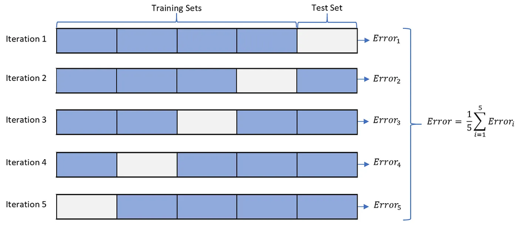

As described in class, *k*-folds cross-validation can help us avoid overfitting and assist with tuning hyperparameters for a given machine learning algorithm. Cross-validation involves randomly dividing the data into *k* “slices” or **folds** of roughly the same size. The first **fold** is treated as a validation set and we train the model on the remainder of the data (i.e., the other 9 slices if *k* = 10). Next, we calculate the Mean Squared Error or another performance metric when the trained model is applied to the one **fold** that has been set aside. We repeat this process *k* times with a different **fold** or “slice” acting as the validation set. This technique provides us with *k* estimates of the test error rate as opposed to the single test error rate that we would otherwise have from the training set.

As mentioned in class, the *caret* package currently supports over 230 algorithms and by setting the **method** argument of the `caret::train` function to “rpart”, we are fitting a simple decision tree model. Because the outcome we are predicting is continuous rather than categorical, it is a regression tree rather than a classification tree.

```r
# Set up for standard, 10 fold cross-validation...
tree.ctrl <- trainControl(method = "cv", number = 10)

tree.model <- train(SalePrice ~ ., data = boston.training %>%
                                  st_drop_geometry() %>%
                                  dplyr::select(SalePrice, LivingArea, Style,
                                               GROSS_AREA, R_TOTAL_RM, NUM_FLOORS,
                                               R_BDRMS, R_FULL_BTH, R_HALF_BTH,
                                               R_KITCH, R_AC, R_FPLACE),
                    method = "rpart",
                    trControl = tree.ctrl,
                    tuneLength = 10)
print(tree.model)
```

```
## CART
##
## 915 samples
##  11 predictor
##
## No pre-processing
## Resampling: Cross-Validated (10 fold)
## Summary of sample sizes: 824, 823, 823, 823, 824, 825, ...
## Resampling results across tuning parameters:
##
##   cp           RMSE      Rsquared   MAE
##   0.002056816  445826.8  0.5606821  214454.3
##   0.003107594  448236.7  0.5552827  215587.8
##   0.003977076  447740.1  0.5560276  215460.5
##   0.004083570  447596.6  0.5559598  216314.7
##   0.005393514  452486.0  0.5453738  217327.5
##   0.012564111  460749.2  0.5217843  223625.0
##   0.014637903  463090.5  0.5152597  225438.2
##   0.044804307  507066.9  0.4061146  246998.1
##   0.051594581  500529.5  0.3993366  247813.0
##   0.389698312  605879.4  0.2623713  285020.1
##
## RMSE was used to select the optimal model using the smallest value.
## The final value used for the model was cp = 0.002056816.
```

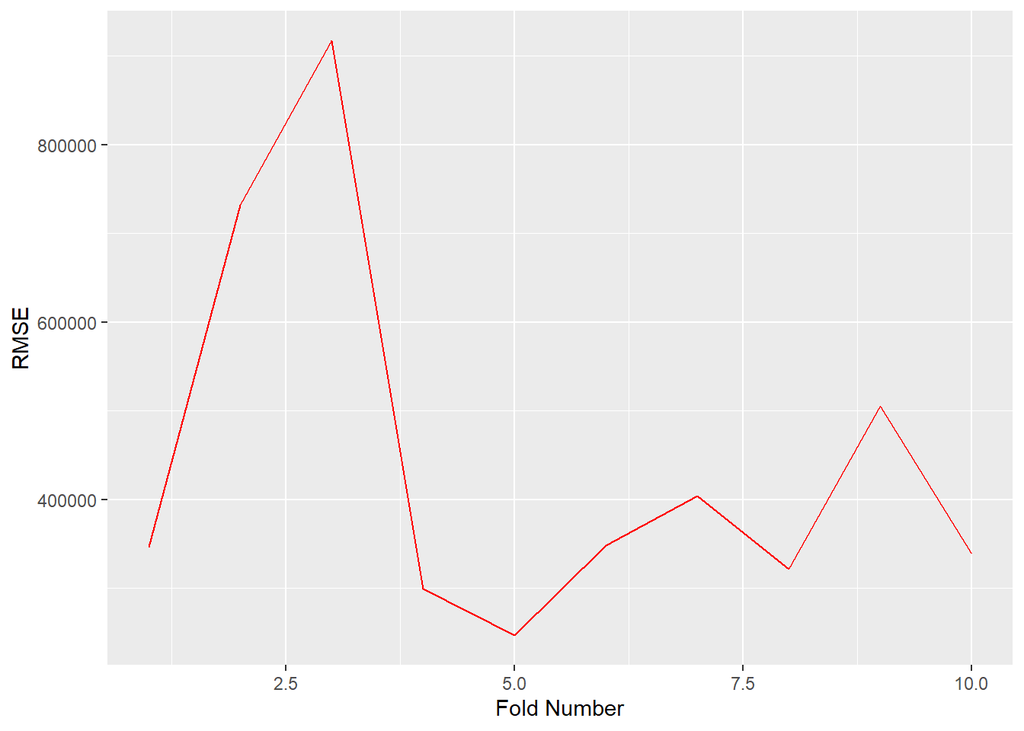

```r
# Do we want more folds? How stable is the model performance based on
# this information?
ggplot(mapping = aes(y = tree.model$resample$RMSE, x = seq(1, 10, 1))) +
  geom_line(color = "red") +
  xlab("Fold Number") + ylab("RMSE")
```

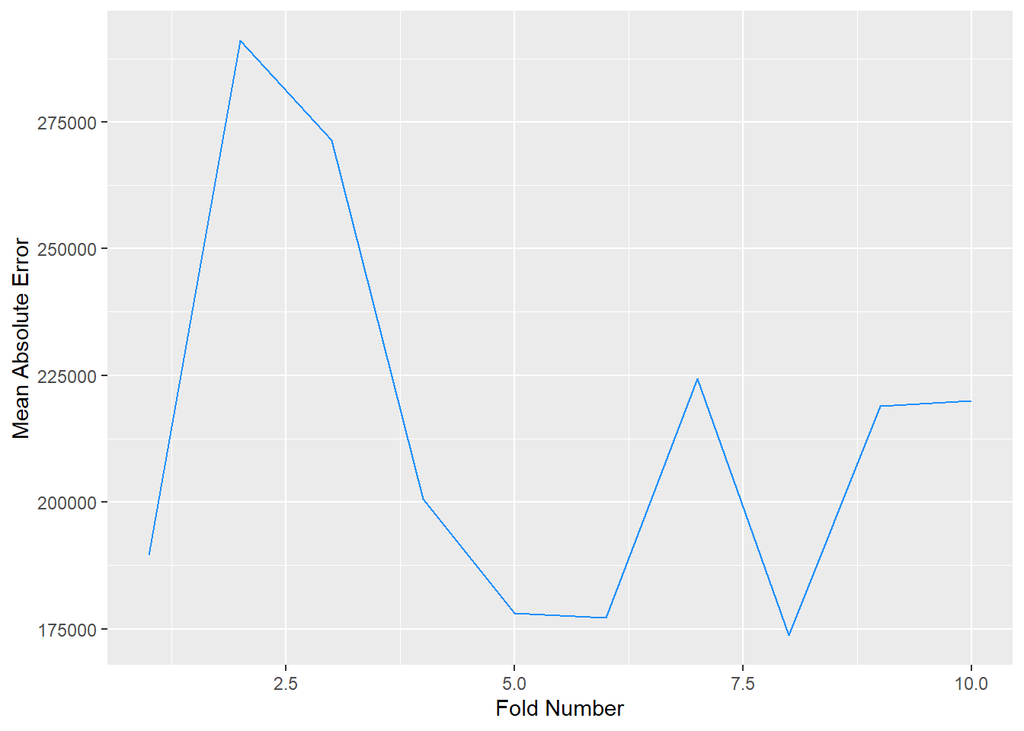

```r
ggplot(mapping = aes(y = tree.model$resample$MAE, x = seq(1, 10, 1))) +
  geom_line(color = "dodgerblue") +
  xlab("Fold Number") + ylab("Mean Absolute Error")
```

## 3.3.2 More feature engineering

The chunk below introduces some mild **feature engineering** in an attempt to boost model fit and predictive capability.

```r
boston.training <-
  boston.training %>%
  mutate(NUM_FLOORS.cat = case_when(
                  NUM_FLOORS >= 0 & NUM_FLOORS < 3  ~ "Up to 2 Floors",
                  NUM_FLOORS >= 3 & NUM_FLOORS < 4  ~ "3 Floors",
                  NUM_FLOORS > 4                    ~ "4+ Floors"))


boston.test <-
  boston.test %>%
  mutate(NUM_FLOORS.cat = case_when(
                  NUM_FLOORS >= 0 & NUM_FLOORS < 3  ~ "Up to 2 Floors",
                  NUM_FLOORS >= 3 & NUM_FLOORS < 4  ~ "3 Floors",
                  NUM_FLOORS > 4                    ~ "4+ Floors"))
```

We then re-run the model with the newly created categorical variable that reflects the number of floors in a home. **Note:** Below we are including **Parcel_No** in the `select` component so that we can link the predicted sales price back to the geometry for mapping purposes, but it is not used as a feature in the model itself.

```r
# Set up for standard, 10 fold cross-validation...
tree.ctrl <- trainControl(method = "cv", number = 10)

tree.model.revised <- train(SalePrice ~ LivingArea + Style + GROSS_AREA + R_TOTAL_RM + NUM_FLOORS.cat +
                                        R_BDRMS + R_FULL_BTH + R_HALF_BTH + R_KITCH + R_AC + R_FPLACE,
                                  data = boston.training %>%
                                  st_drop_geometry() %>%
                                  drop_na() %>%
                                  dplyr::select(SalePrice, LivingArea, Style,
                                               GROSS_AREA, R_TOTAL_RM, NUM_FLOORS.cat,
                                               R_BDRMS, R_FULL_BTH, R_HALF_BTH,
                                               R_KITCH, R_AC, R_FPLACE, Parcel_No),
                    method = "rpart",
                    trControl = tree.ctrl,
                    tuneLength = 10)
print(tree.model.revised)
```

```
## CART
##
## 870 samples
##  11 predictor
##
## No pre-processing
## Resampling: Cross-Validated (10 fold)
## Summary of sample sizes: 782, 784, 782, 783, 783, 784, ...
## Resampling results across tuning parameters:
##
##   cp           RMSE      Rsquared    MAE
##   0.005110437  431658.9  0.22156127  213366.5
##   0.005147833  431658.9  0.22156127  213366.5
##   0.007421923  430654.5  0.22515480  213233.5
##   0.017352120  437982.1  0.19885291  217122.3
##   0.022668291  449091.3  0.15118822  223885.1
##   0.032454165  455434.5  0.13631585  227877.7
##   0.037136190  459009.1  0.13066217  229659.6
##   0.047398083  479054.5  0.07119198  235575.8
##   0.108911292  484443.8  0.04294848  240742.5
##   0.112538619  485707.9  0.04294848  241759.4
##
## RMSE was used to select the optimal model using the smallest value.
## The final value used for the model was cp = 0.007421923.
```

# 3.4 Cross-validation & return to goodness of fit

According to Steif, “…*a generalizable model is one that accurately predicts on new data*…” and “…*a generalizable model is also one that predicts with comparable accuracy across different groups*…”. Mean Absolute Error [(MAE)](https://en.wikipedia.org/wiki/Mean_absolute_error) is a fundamental measure of accuracy and is one of the metrics generated by most [machine learning packages](https://cran.r-project.org/web/views/MachineLearning.html) by default. MAE measures the average magnitude of the errors in a set of predictions, without considering their direction. It is the average over the test sample of the absolute differences between prediction and actual observation where all individual differences have equal weight. By contrast, since the errors are squared before they are averaged, the RMSE gives a relatively high weight to large errors.

## 3.4.1 Accuracy - Mean Absolute Error

We fit the model on the training dataset in the above code chunk, then apply it to the test dataset in the code chunk below using the `predict` function. The MAE and the Absolute Percent Error are also calculated based on the known sales price **AND** the predicted sale prices from the model. These metrics give us a sense of how well the model performs when applied to **new** data.

```r
boston.test.no.geometry <-
  boston.test %>%
  st_drop_geometry() %>%
  drop_na() %>%
  dplyr::select(SalePrice, LivingArea, Style, GROSS_AREA, R_TOTAL_RM, NUM_FLOORS.cat,
                                               R_BDRMS, R_FULL_BTH, R_HALF_BTH,
                                               R_KITCH, R_AC, R_FPLACE, Parcel_No)

tree.model.test <- predict(tree.model.revised, boston.test.no.geometry)

outputPredictions <- boston.test.no.geometry %>%
  mutate(
         SalePrice.AbsError = abs(tree.model.test - boston.test.no.geometry$SalePrice),
         SalePrice.APE = (abs(tree.model.test - boston.test.no.geometry$SalePrice)) / tree.model.test) %>%
  filter(SalePrice < 5000000)


# Assess accuracy...
mean(outputPredictions$SalePrice.AbsError, na.rm = T)
```

```
## [1] 190688.1
```

```r
mean(outputPredictions$SalePrice.APE, na.rm = T)
```

```
## [1] 0.2750571
```

In the above code chunk we see that on average, the model predictions are off by over $190,000 which translates to about 27.5 percent 😢 This is not super surprising because single decision tree models are typically not among those with the greatest predictive capacity. During the next session, we will introduce the [random forest algorithm](https://www.ibm.com/topics/random-forest#:~:text=Random%20forest%20is%20a%20commonly,both%20classification%20and%20regression%20problems.) which uses decisions trees as a building block to boost predictive capacity.

```r
# install.packages("rattle")

library(rattle)
```

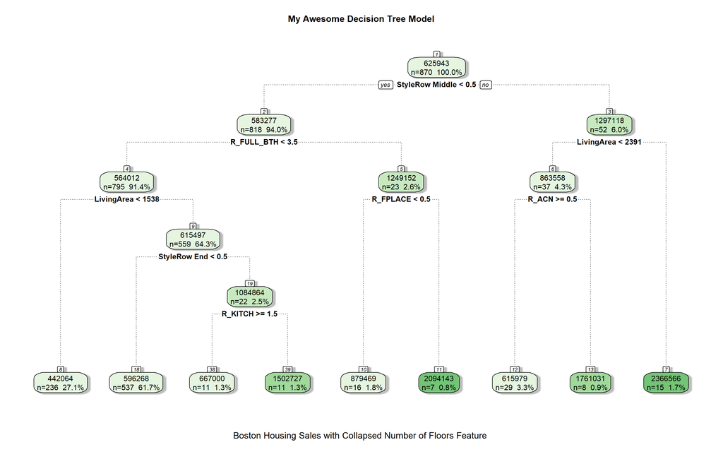

```r
fancyRpartPlot(tree.model.revised$finalModel, main = "My Awesome Decision Tree Model", sub = "Boston Housing Sales with Collapsed Number of Floors Feature", digits = -3)
```

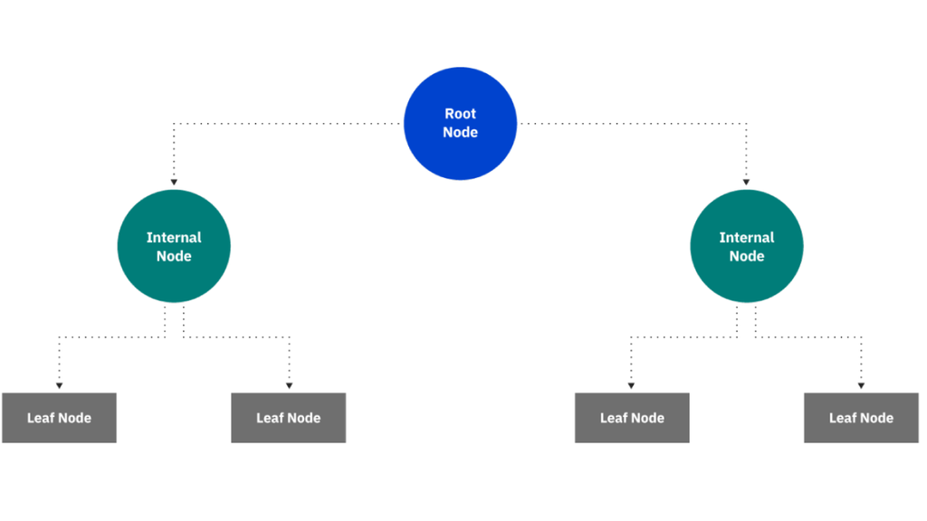

At each internal node (i.e., between the root node and the leaves or terminal nodes), the plot displays the number and percentage of observations that “flow” through that node of the decision tree, as well as what the model would predict as the sales price.

### **Your Turn**

You have reached the end! 💪